# Text Prediction

Mrugank Akarte  
June 12, 2017

### Introduction

- The application is built to predict the next word based on some training data. Data for training was downloaded from the [link](https://d396qusza40orc.cloudfront.net/dsscapstone/dataset/Coursera-SwiftKey.zip) provided by Coursera.
- This data includes 899288 blogs, 77259, news articles and 23360148 tweets. For this project only blogs and news articles were used for training.
- 5-gram Stupid Backoff algorithm was used to predict the next word.
- Application can be found [here](https://mrugankakarte.shinyapps.io/text_predictor/)

### 5-gram Stupid Backoff Model

The following formula was used to rank the next word [[1]](http://www.aclweb.org/anthology/D07-1090.pdf)

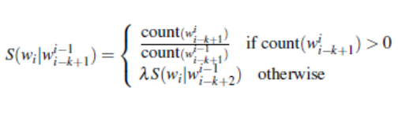

The idea is that, the input text is first compared with 5-grams table and all the similar 5-grams are filtered and a score is calculated for last word using the formula. If sufficient results are not found then the model backoffs i.e. it checks in 4-gram table and so on.

All n-grams with frequency less than 3 were removed to reduce the size of tables and improve the speed of application.

### Benchmarking results

Hfoffani's next word prediction benchmark [[2]](https://github.com/hfoffani/dsci-benchmark) was used to test out the model.100 blogs were used in benchmarking, for a total 2433 predictions. The results obtained for the model are as follows:

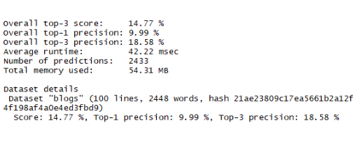

On an average accuracy of 14-15% is obtained with model. Time taken for each prediction is around 40msec and memory used was only 55Mb. This suggests that more data can be used to improve the accuracy.

### References

[1]. “Large language models in machine translation” by T. Brants et al, in EMNLP/CoNLL 2007 : http://www.aclweb.org/anthology/D07-1090.pdf  
[2]. Next word prediction benchmark : https://github.com/hfoffani/dsci-benchmark

*Future Scope* : Using RNN for word/ character prediction for high accuracy.